# **Data Processing With Python**

## Contents

I. Trend Of Programming Languages

II. Why Python?

III. Some Python Basics

IV. "Talk is cheap. Show me the code. "

V. Packages We Use

VI. Pandas

VII. Numpy And Matplotlib

VIII. Jupyter Notebook

IX. How To Get Python And Packages?

X. How To Get Started?

Let`s Play With Python

Recommanded Solutions

## I. Trend Of Programming Languages

### 1. [TIOBE Index](https://tiobe.com/tiobe-index/)

[figure not shown]

### 2. Long Term History Of Most Popular Languages

[figure not shown]

## II. Why Python？

### *The Zen Of Python*

*Beautiful is better than ugly.*

*Explicit is better than implicit.*

*Simple is better than complex.*

*Complex is better than complicated.*

*Flat is better than nested.*

*Sparse is better than dense.*

*Readability counts.*

*...*

### Summary

- Friendly syntax >>> Easy to learn
- Open >>> Powerful (numerous packages, 131315 packages in March 6th, 2018 in total)
- Fast to develop a project
- Plays well with others (Glue language: Cython, Rpy2, Jython, PyMongo)
- Cloud computing, Machine Learning, Data Mining, Natural Language Processing, etc.

## III. Some Python Basics

### 1. Language Style

[figure not shown]

### 2. Module

```python
import pandas
df = pandas.DataFrame()
```

```python
import pandas as pd
df = pd.DataFrame()
```

```python
from pandas import *
df = DataFrame()
```

```python
from pandas import DataFrame
df = DataFrame()
```

```python
from pandas import DataFrame as DF
df = DF()
```

### 3. Type Of Data

```python
num = 3 # number, includes int、float、bool and complex
print num, type(num)
```

```
3 <type 'int'>
```

```python
list_ = ['Fibonacci', 1, 1, 2, 3, 5, 8] # list
print list_, type(list_)
```

```
['Fibonacci', 1, 1, 2, 3, 5, 8] <type 'list'>
```

```python
str_ = 'Hello' # str
print str_, type(str_)
```

```
Hello <type 'str'>
```

```python
tuple_ = (10, 'a') # tuple
print tuple_, type(tuple_)
```

```
(10, 'a') <type 'tuple'>
```

```python
dict_= {'key1':'value1', 'key2':'value2', 'key3':'value3'} # dictionary
print dict_, type(dict_)
```

```
{'key3': 'value3', 'key2': 'value2', 'key1': 'value1'} <type 'dict'>
```

```python
set_ = {1, 2, 1, 3} # set
print set_, type(set_)
```

```
set([1, 2, 3]) <type 'set'>
```

### 4. Operators

Arithmetic Operators: +, -, /, %, **, //

Comparison Operators: ==, !=, >=, <=, >, <

Assignment Operators: =, +=, -=, /=, %=, **=, //=

Bitwise Operators: &, |, ^, <<, >>

Logical operators: not, or, and

Membership Operators: in, not in

Identity Operators: is, is not

### 5. Function And Arguements

```python
def fun(a, b, c=20, *args, **kwargs): # Required arguments， Default arguments， Variable-length arguments
    print 'a =', a, ' b =', b, ' c =', c, ' args >>>', args, ' kwargs >>>',kwargs
```

```python
fun()
```

```
---------------------------------------------------------------------------
TypeError                                 Traceback (most recent call last)
<ipython-input-13-d9f830ba61f1> in <module>()
----> 1 fun()

TypeError: fun() takes at least 2 arguments (0 given)
```

```python
fun(1, 2)
```

```
a = 1  b = 2  c = 20  args >>> ()  kwargs >>> {}
```

```python
fun(b=2, a=1)
```

```
a = 1  b = 2  c = 20  args >>> ()  kwargs >>> {}
```

```python
fun(1, 2, 3, 4, 5)
```

```
a = 1  b = 2  c = 3  args >>> (4, 5)  kwargs >>> {}
```

```python
fun(1, 2, 3, k='key', n='num')
```

```
a = 1  b = 2  c = 3  args >>> ()  kwargs >>> {'k': 'key', 'n': 'num'}
```

### 6. Control

BTW, break/continue can be used as usual.

if [-elif-else]:

```
if condition1:
    statement1
elif condition2:
    statement2
else:
    statement3
```

while [-else]:

```
while condition:
    statement1
else：
    statement2
```

for [-else]:

```
for variable in sequence:
    statement1
else:
    statement2
```

### 7. IO Of File

[figure not shown]

```python
f = open(r'F:\Git\DataProcessingWithPython\The Zen Of Python.txt', 'r')
content = f.read()
print f.tell()
f.close()# When you’re done with a file, call f.close() to close it and free up any system resources taken up by the open file.
```

```
233
```

```python
print content
```

```
Beautiful is better than ugly.

Explicit is better than implicit.

Simple is better than complex.

Complex is better than complicated.

Flat is better than nested.

Sparse is better than dense.

Readability counts.

...
```

```python
f.readlines()
```

```
---------------------------------------------------------------------------
ValueError                                Traceback (most recent call last)
<ipython-input-20-055d0c37aeda> in <module>()
----> 1 f.readlines()

ValueError: I/O operation on closed file
```

```python
with open(r'F:\Git\DataProcessingWithPython\The Zen Of Python.txt', 'r') as f: # without f.close() is OK
    print f.tell()
    c1 = f.readline()
    print f.tell()
```

```
0
32
```

```python
print c1
```

```
Beautiful is better than ugly.
```

```python
with open(r'F:\Git\DataProcessingWithPython\The Zen Of Python.txt', 'r') as f:
    f.seek(34, 0)
    c2 = f.readline()
    print f.tell()
```

```
69
```

```python
print c2
```

```
Explicit is better than implicit.
```

```python
content
```

```
'Beautiful is better than ugly.\n\nExplicit is better than implicit.\n\nSimple is better than complex.\n\nComplex is better than complicated.\n\nFlat is better than nested.\n\nSparse is better than dense.\n\nReadability counts.\n\n...'
```

## IV. "Talk is cheap. Show me the code. "

### 1. Sequence

Sequence share following methods

```python
list_ = ['Fibonacci', 1, 1, 2, 3, 5, 8] # list
str_ = 'Hello' # str
tuple_ = (10, 'a') # tuple
```

```python
list_[1:6] # list_[start:end:step]
```

```
[1, 1, 2, 3, 5]
```

```python
list_[::-1]
```

```
[8, 5, 3, 2, 1, 1, 'Fibonacci']
```

```python
tuple_ * 3
```

```
(10, 'a', 10, 'a', 10, 'a')
```

```python
str_ + ' Word!'
```

```
'Hello Word!'
```

```python
'i' in 'Fibonacci'
```

```
True
```

```python
len('Fibonacci')
```

```
9
```

```python
', '.join(['a', 'b', 'c', 'd', 'e'])
```

```
'a, b, c, d, e'
```

Something interesting

```python
'a-b-c-d-e'.split('-')
```

```
['a', 'b', 'c', 'd', 'e']
```

```python
'Emmmmm'.strip('m')
```

```
'E'
```

```python
'Data Processing With Python'.istitle()
```

```
True
```

```python
'A'.islower()
```

```
False
```

```python
r'F:\Lab\preset'
```

```
'F:\\Lab\\preset'
```

*"In Python, it’s all about the attributes. "*

```python
dir('Python')
```

```
['__add__',
 '__class__',
 '__contains__',
 '__delattr__',
 '__doc__',
 '__eq__',
 '__format__',
 '__ge__',
 '__getattribute__',
 '__getitem__',
 '__getnewargs__',
 '__getslice__',
 '__gt__',
 '__hash__',
 '__init__',
 '__le__',
 '__len__',
 '__lt__',
 '__mod__',
 '__mul__',
 '__ne__',
 '__new__',
 '__reduce__',
 '__reduce_ex__',
 '__repr__',
 '__rmod__',
 '__rmul__',
 '__setattr__',
 '__sizeof__',
 '__str__',
 '__subclasshook__',
 '_formatter_field_name_split',
 '_formatter_parser',
 'capitalize',
 'center',
 'count',
 'decode',
 'encode',
 'endswith',
 'expandtabs',
```

[output cut: 16 more lines]

```
 'rfind',
 'rindex',
 'rjust',
 'rpartition',
 'rsplit',
 'rstrip',
 'split',
 'splitlines',
 'startswith',
 'strip',
 'swapcase',
 'title',
 'translate',
 'upper',
 'zfill']
```

```python
'Python'.__len__() # len('Python')
```

```
6
```

```python
import os

dir1 = 'F:\Git\DataProcessingWithPython\exammode.db' #复制文件所在目录+手动输入DB文件名
dir2 = 'F:\Git\DataProcessingWithPython\exammode.db' #文件属性/安全/对象名称获取的路径

print os.path.exists(dir1), os.path.exists(dir2)
```

```
True False
```

```python
print hex(dir1.__hash__()), hex(dir2.__hash__())
```

```
0x7466e790 -0x4d1c4926
```

```python
import chardet

print chardet.detect(dir1), chardet.detect(dir2)
```

```
{'confidence': 1.0, 'language': '', 'encoding': 'ascii'} {'confidence': 0.7525, 'language': '', 'encoding': 'utf-8'}
```

### 2. Traversal

```python
range(5) # equal to range(0, 5, 1), [0, 5)
```

```
[0, 1, 2, 3, 4]
```

```python
top5 = ['Java', 'C', 'C++', 'Python', 'C#']
for item in top5:
    print item
```

```
Java
C
C++
Python
C#
```

```python
for item in sorted(top5):
    print item
```

```
C
C#
C++
Java
Python
```

```python
for item in reversed(top5):
    print item
```

```
C#
Python
C++
C
Java
```

```python
top5
```

```
['Java', 'C', 'C++', 'Python', 'C#']
```

```python
for offset, item in enumerate(top5):
    print offset, '>>>', item
```

```
0 >>> Java
1 >>> C
2 >>> C++
3 >>> Python
4 >>> C#
```

```python
dic = dict(enumerate(top5))
dic
```

```
{0: 'Java', 1: 'C', 2: 'C++', 3: 'Python', 4: 'C#'}
```

```python
dic = dict(zip(range(5), top5))
dic
```

```
{0: 'Java', 1: 'C', 2: 'C++', 3: 'Python', 4: 'C#'}
```

```python
for key, value in dic.iteritems():
    print key, '>>>', value
```

```
0 >>> Java
1 >>> C
2 >>> C++
3 >>> Python
4 >>> C#
```

```python
for x, y, z in zip([10, 11, 12], 'ABC', ('1010', '1011', '1100')):
    print 'DEC:', x, ' HEX:', y, ' BIN:', z
```

```
DEC: 10  HEX: A  BIN: 1010
DEC: 11  HEX: B  BIN: 1011
DEC: 12  HEX: C  BIN: 1100
```

### 3. "Pythonic" Code

```python
0.1 < 0.3 < 0.5
```

```
True
```

```python
a, b, c = 'ABC', 456, ('a')
print 'a =', a
print 'b =', b
print 'c =', c
```

```
a = ABC
b = 456
c = a
```

```python
x, y = 1, 0
x, y = y, x
print 'x =', x, ' y =', y
```

```
x = 0  y = 1
```

```python
s = '''CREATE TABLE "schema_version" (
    "name" TEXT NOT NULL PRIMARY KEY,
    "version" INTEGER NOT NULL,
    "migration" INTEGER NOT NULL);'''
print s
```

```
CREATE TABLE "schema_version" (
    "name" TEXT NOT NULL PRIMARY KEY,
    "version" INTEGER NOT NULL,
    "migration" INTEGER NOT NULL);
```

```python
[x for x in range(18) if x % 2 == 1]
```

```
[1, 3, 5, 7, 9, 11, 13, 15, 17]
```

```python
func = lambda str_ : str_.lower() # lambda
func('AbCdE')
```

```
'abcde'
```

```python
map(str.upper, 'Hello Word!') # map
```

```
['H', 'E', 'L', 'L', 'O', ' ', 'W', 'O', 'R', 'D', '!']
```

```python
filter(str.isupper, 'Hello Word!') # filter
```

```
'HW'
```

```python
reduce(lambda x, y : x*y, [1, 2, 3, 4, 5]) # reduce, to caculate 5!
```

```
120
```

## V. Packages We Use

[SciPy](https://www.scipy.org/!)(pronounced “Sigh Pie”) is a Python-based ecosystem of open-source software for **mathematics**, **science**, and **engineering**.

### 1. Pandas

Pandas(Python Data Analysis Library) is an open source, BSD-licensed library providing high-performance, easy-to-use **data structures** and **data analysis tools** for the Python programming language.

### 2. Numpy

NumPy is the fundamental package for **scientific computing** with Python. It contains among other things:

- a powerful N-dimensional array object
- tools for integrating C/C++ and Fortran code
- useful linear algebra, Fourier transform, and random number capabilities

...

### 3. Matplotlib

[figure not shown]

Matplotlib is a Python **2D plotting library** which produces **publication quality figures** in a variety of hardcopy formats and interactive environments across platforms.

### 4. IPython

[figure not shown]

In 2014, Fernando Pérez announced a spin-off project from IPython called *Project Jupyter*. IPython will continue to exist as a Python shell and a kernel for Jupyter, while the notebook and other language-agnostic parts of IPython will move under the Jupyter name. Jupyter added support for **Julia**, **R**, **Haskell** and **Ruby**.

[figure not shown]

### 5. Scipy

The SciPy library is one of the core packages that make up the SciPy stack. It provides many user-friendly and efficient numerical routines such as routines for numerical integration and optimization.

- constants: physical constants and conversion factors
- cluster: hierarchical clustering, vector quantization, K-means
- fftpack: Discrete Fourier Transform algorithms
- optimize: optimization algorithms including linear programming
- signal: signal processing tools
- ndimage: various functions for multi-dimensional image processing
- sparse: sparse matrix and related algorithms

...

## VI. Pandas

### 1. Library Highlights

- A fast and efficient **DataFrame** object for data manipulation with integrated indexing
- Tools for **reading and writing data** between in-memory data structures and different formats: CSV and text files, Microsoft Excel, SQL databases, and the fast HDF5 format
- Flexible **reshaping and pivoting** of data sets
- Highly optimized for performance, with critical code paths written in **Cython or C**
- High performance **merging and joining** of data sets

...

### 2. DataFrame

[figure not shown]

```python
import pandas as pd

examModeTable = pd.read_excel(r'F:\Git\DataProcessingWithPython\ExamModeSpec.xlsx', header=3)
examModeTable.head(8)
```

|  | Product | Purpose | Application | Chinese | Abbreviation | English | AppField | App2Exam | Unnamed: 8 | Unnamed: 9 | ... | Unnamed: 63 | Unnamed: 64 | Unnamed: 65 | Unnamed: 66 | Unnamed: 67 | Unnamed: 68 | Unnamed: 69 | Unnamed: 70 | Unnamed: 71 | Unnamed: 72 |
| --- | --- | --- | --- | --- | --- | --- | --- | --- | --- | --- | --- | --- | --- | --- | --- | --- | --- | --- | --- | --- | --- |
| NaN | # | # | # | # | # | # | # | NaN | NaN | NaN | ... | NaN | NaN | NaN | NaN | NaN | NaN | 测量 | 注释 | 体位图 | 报告 |
| NaN | * | HUMAN | GENERAL | 系统测试 | SysTest | System Test | ABD | NaN | √ | 0.0 | ... | 0.0 | √ | 0.0 | √ | 0.0 | NaN | ABD | Abdomen | Abdomen | 腹部超声报告 |
| NaN | * | HUMAN | GENERAL | 成人腹部 | Adult ABD | Adult Abdominal | ABD | √ | Default | 0.0 | ... | NaN | √ | 0.0 | NaN | NaN | NaN | CAR | Cardiac | Cardiology | 心脏超声报告 |
| NaN | * | HUMAN | * | 成人心脏 | Adult Cardiac | Adult Cardiac | Cardiac | √ | NaN | NaN | ... | NaN | NaN | NaN | NaN | NaN | NaN | GYN | Gyn | Gyn | 妇科超声报告 |
| NaN | * | HUMAN | * | 妇科 | GYN | GYN | GYN | √ | √ | 1.0 | ... | NaN | Default[ANE] | 1.0 | NaN | NaN | NaN | OB1 | OB | OB | 产科超声报告 |
| NaN | * | HUMAN | GENERAL | 早孕 | OB1 | OB1 | OB | NaN | √ | 1.0 | ... | NaN | Default | 1.0 | NaN | NaN | NaN | OB2/3 | OB | OB | 产科超声报告 |
| NaN | * | HUMAN | GENERAL | 中晚孕 | OB2/3 | OB2/3 | OB | √ | √ | 1.0 | ... | NaN | √ | 1.0 | NaN | NaN | NaN | OB2/3 | OB | OB | 产科超声报告 |
| NaN | * | HUMAN | GENERAL | 胎儿心脏 | Fetal Cardiac | Fetal Cardiac | OB | NaN | √ | 2.0 | ... | NaN | √ | 2.0 | NaN | NaN | NaN | URO | Kidney | Kidney | 泌尿超声报告 |

8 rows × 73 columns

```python
examModeTable = examModeTable.ix[:, ['Chinese', 'Abbreviation']]
examModeTable.head(8)
```

|  | Chinese | Abbreviation |
| --- | --- | --- |
| NaN | # | # |
| NaN | 系统测试 | SysTest |
| NaN | 成人腹部 | Adult ABD |
| NaN | 成人心脏 | Adult Cardiac |
| NaN | 妇科 | GYN |
| NaN | 早孕 | OB1 |
| NaN | 中晚孕 | OB2/3 |
| NaN | 胎儿心脏 | Fetal Cardiac |

```python
examModeId = pd.read_csv((r'F:\Git\DataProcessingWithPython\examid.txt'), header=None, names=['Abbreviation', 'examModeId'])
examModeId.head(8)
```

|  | Abbreviation | examModeId |
| --- | --- | --- |
| 0 | Adult ABD | c5ddb1fa-704b-31b2-9510-2e75bdd16fee |
| 1 | Adult Cardiac | 5cbcf239-7c62-3bb9-bb15-c24429d60d84 |
| 2 | GYN | 48957ed3-634a-3c70-9444-9de798b771df |
| 3 | OB1 | b2c27741-5fc1-3bd1-a097-90e0cbc95a11 |
| 4 | OB2/3 | 015b044d-b456-375f-86f1-280987bbc6d1 |
| 5 | Fetal Cardiac | bc00dae4-8072-39f1-bd6d-4d011f6392b6 |
| 6 | Kidney | 7bcd41db-96d1-3b94-af58-b951d03951eb |
| 7 | Prostate | 34882457-b208-3dba-9aa4-49cb38f0aff9 |

```python
examModeTable = pd.merge(examModeId, examModeTable, on='Abbreviation')
examModeTable.head(8)
```

|  | Abbreviation | examModeId | Chinese |
| --- | --- | --- | --- |
| 0 | Adult ABD | c5ddb1fa-704b-31b2-9510-2e75bdd16fee | 成人腹部 |
| 1 | Adult Cardiac | 5cbcf239-7c62-3bb9-bb15-c24429d60d84 | 成人心脏 |
| 2 | GYN | 48957ed3-634a-3c70-9444-9de798b771df | 妇科 |
| 3 | OB1 | b2c27741-5fc1-3bd1-a097-90e0cbc95a11 | 早孕 |
| 4 | OB2/3 | 015b044d-b456-375f-86f1-280987bbc6d1 | 中晚孕 |
| 5 | Fetal Cardiac | bc00dae4-8072-39f1-bd6d-4d011f6392b6 | 胎儿心脏 |
| 6 | Kidney | 7bcd41db-96d1-3b94-af58-b951d03951eb | 肾脏 |
| 7 | Prostate | 34882457-b208-3dba-9aa4-49cb38f0aff9 | 前列腺 |

```python
df = pd.read_csv(r'F:\Git\DataProcessingWithPython\imgPara.csv', encoding='gb2312').ix[:, ['probeName', 'Chinese', 'imgParaName', 'imgParaVal']]
df.head(8)
```

|  | probeName | Chinese | imgParaName | imgParaVal |
| --- | --- | --- | --- | --- |
| 0 | L10-5 | 乳腺 | IdxPW_Map | 2 |
| 1 | L10-5 | 乳腺 | IdxD2d_Sensitivity_P | 3 |
| 2 | L10-5 | 乳腺 | UIC_Baseline | 10 |
| 3 | L10-5 | 乳腺 | IdxM_Map | 0 |
| 4 | L10-5 | 乳腺 | IdxTis | 2 |
| 5 | L10-5 | 乳腺 | IdxD2d_Scale | 0 |
| 6 | L10-5 | 乳腺 | IdxPW_WF_CW | 98 |
| 7 | L10-5 | 乳腺 | UID_BaseLine_CW | 4 |

```python
df = df.set_index(['probeName', 'Chinese', 'imgParaName'])
df.head(8)
```

| probeName | Chinese | imgParaName | imgParaVal |
| --- | --- | --- | --- |
| L10-5 | 乳腺 | IdxPW_Map | 2 |
|  |  | IdxD2d_Sensitivity_P | 3 |
|  |  | UIC_Baseline | 10 |
|  |  | IdxM_Map | 0 |
|  |  | IdxTis | 2 |
|  |  | IdxD2d_Scale | 0 |
|  |  | IdxPW_WF_CW | 98 |
|  |  | UID_BaseLine_CW | 4 |

```python
df = df.unstack()
df.head(8)
```

| probeName | imgParaName Chinese | imgParaVal IdxAMM_Speed | imgParaVal IdxB_Colorize | imgParaVal IdxB_Depth | imgParaVal IdxB_ExtFOV | imgParaVal IdxB_FOVPercent | imgParaVal IdxB_FUND_Opt | imgParaVal IdxB_LineDensity | imgParaVal IdxB_Map | imgParaVal IdxB_Persist | imgParaVal IdxB_Steer | imgParaVal ... | imgParaVal ecg_2d_speed | imgParaVal ecg_gain | imgParaVal ecg_y_pos | imgParaVal harmonic | imgParaVal middleline | imgParaVal mode_3d_image_layout | imgParaVal pw_multiplex | imgParaVal thermal_index | imgParaVal timemark | imgParaVal viewscale |
| --- | --- | --- | --- | --- | --- | --- | --- | --- | --- | --- | --- | --- | --- | --- | --- | --- | --- | --- | --- | --- | --- | --- |
| C5-1 | ICU | NaN | 0.0 | 10.0 | 0.0 | 3.0 | 4.0 | 2.0 | 9.0 | 3.0 | 0.0 | ... | 5.0 | 1.0 | 20.0 | 1.0 | 0.0 | NaN | 0.0 | 0.0 | 0.0 | 1.0 |
|  | 中晚孕 | NaN | 0.0 | 10.0 | 0.0 | 3.0 | 4.0 | 2.0 | 9.0 | 3.0 | 0.0 | ... | 5.0 | 1.0 | 20.0 | 1.0 | 0.0 | NaN | 0.0 | 0.0 | 0.0 | 1.0 |
|  | 前列腺 | NaN | 0.0 | 9.0 | 0.0 | 3.0 | 4.0 | 2.0 | 4.0 | 1.0 | 0.0 | ... | 5.0 | 1.0 | 20.0 | 1.0 | 0.0 | NaN | 0.0 | 0.0 | 0.0 | 1.0 |
|  | 妇科 | NaN | 0.0 | 9.0 | 0.0 | 3.0 | 4.0 | 2.0 | 9.0 | 3.0 | 0.0 | ... | 5.0 | 1.0 | 20.0 | 1.0 | 0.0 | NaN | 0.0 | 0.0 | 0.0 | 1.0 |
|  | 小儿腹部 | NaN | 0.0 | 7.0 | 0.0 | 2.0 | 4.0 | 2.0 | 5.0 | 3.0 | 0.0 | ... | 5.0 | 1.0 | 20.0 | 1.0 | 0.0 | NaN | 0.0 | 0.0 | 0.0 | 1.0 |
|  | 急诊FAST | NaN | 1.0 | 10.0 | 0.0 | 3.0 | 1.0 | 2.0 | 9.0 | 4.0 | 0.0 | ... | 5.0 | 1.0 | 20.0 | 1.0 | 0.0 | NaN | 0.0 | 0.0 | 0.0 | 1.0 |
|  | 成人腹部 | NaN | 0.0 | 10.0 | 0.0 | 3.0 | 1.0 | 2.0 | 5.0 | 1.0 | 0.0 | ... | 5.0 | 1.0 | 20.0 | 1.0 | 0.0 | NaN | 0.0 | 0.0 | 0.0 | 1.0 |
|  | 早孕 | NaN | 0.0 | 9.0 | 0.0 | 3.0 | 3.0 | 2.0 | 9.0 | 4.0 | 0.0 | ... | 5.0 | 1.0 | 20.0 | 1.0 | 0.0 | NaN | 0.0 | 0.0 | 0.0 | 1.0 |

8 rows × 251 columns

[figure not shown]

## VII. Numpy And Matplotlib

```python
import numpy as np
import matplotlib.pyplot as plt
```

```python
a = np.array([[0, -1, 2], (3, 4, -5), [-6, 7, 8], (-9, 10, 11)])
a
```

```
array([[ 0, -1,  2],
       [ 3,  4, -5],
       [-6,  7,  8],
       [-9, 10, 11]])
```

```python
a[1:3, 0:3]
```

```
array([[ 3,  4, -5],
       [-6,  7,  8]])
```

```python
a.shape
```

```
(4, 3)
```

```python
a.T
```

```
array([[ 0,  3, -6, -9],
       [-1,  4,  7, 10],
       [ 2, -5,  8, 11]])
```

```python
a.sum()
```

```
24
```

```python
a.reshape(6, 2)
```

```
array([[ 0, -1],
       [ 2,  3],
       [ 4, -5],
       [-6,  7],
       [ 8, -9],
       [10, 11]])
```

```python
a >= 0
```

```
array([[ True, False,  True],
       [ True,  True, False],
       [False,  True,  True],
       [False,  True,  True]])
```

```python
a * (a >= 0)
```

```
array([[ 0,  0,  2],
       [ 3,  4,  0],
       [ 0,  7,  8],
       [ 0, 10, 11]])
```

```python
np.zeros([2, 6])
```

```
array([[0., 0., 0., 0., 0., 0.],
       [0., 0., 0., 0., 0., 0.]])
```

```python
np.ones((2, 3, 4), dtype=np.int8) # dtype can also be specified
```

```
array([[[1, 1, 1, 1],
        [1, 1, 1, 1],
        [1, 1, 1, 1]],

       [[1, 1, 1, 1],
        [1, 1, 1, 1],
        [1, 1, 1, 1]]], dtype=int8)
```

```python
np.linspace(0, np.pi, 4)
```

```
array([0.        , 1.04719755, 2.0943951 , 3.14159265])
```

```python
np.arange(10, 30, 5)
```

```
array([10, 15, 20, 25])
```

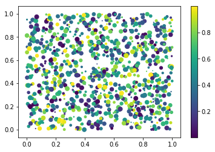

```python
x = np.random.rand(1000)
y = np.random.rand(1000)
size = np.random.rand(1000) * 50
colour = np.random.rand(1000)
plt.scatter(x, y, size, colour)
plt.colorbar()
plt.show()
```

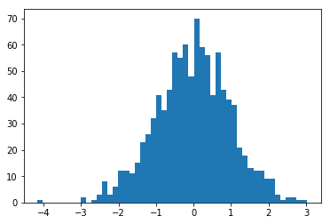

```python
x = np.random.randn(1000)
plt.hist(x, 50)
plt.show()
```

## VIII. Jupyter Notebook

```python
top5?
# func??
```

```python
%timeit range(1000)
```

```
100000 loops, best of 3: 7.87 µs per loop
```

```python
%pwd
```

```
u'F:\\OneDrive\\Python'
```

```python
%cd F:\Git\DataProcessingWithPython
```

```
F:\Git\DataProcessingWithPython
```

```python
!dir
```

```
 驱动器 F 中的卷是 File
 卷的序列号是 7AF9-E837

 F:\Git\DataProcessingWithPython 的目录

2018/03/20 周二  08:57    <DIR>          .
2018/03/20 周二  08:57    <DIR>          ..
2018/03/15 周四  11:47           107,545 AnacondaApp.jpg
2018/03/15 周四  11:45           303,106 AnacondaEnv.png
2018/03/15 周四  14:09            31,974 AnacondaInstall.jpg
2018/03/07 周三  15:04            72,709 DataFrame.png
2018/01/04 周四  16:30             2,171 drawFigure.py
2018/01/31 周三  14:44             3,350 examid.txt
2018/02/06 周二  11:20         1,884,160 exammode.db
2018/02/12 周一  13:38            40,311 ExamModeSpec.xlsx
2018/03/07 周三  15:38         1,888,815 imgPara.csv
2018/03/06 周二  16:23             8,553 indexOfFeb2018.png
2018/03/14 周三  18:03            67,445 IO.png
2018/03/14 周三  14:43            26,576 languageStyle.png
2018/03/06 周二  15:20             5,548 longTermHistory.png
2018/03/15 周四  11:28           141,562 packagesManager.png
2018/03/15 周四  14:06            40,803 py2install.png
2018/03/15 周四  14:07            57,027 py3install.png
2018/03/16 周五  15:28            30,601 pyinstaller.png
2018/03/07 周三  15:57            73,927 stack.png
2018/03/15 周四  09:20               233 The Zen Of Python.txt
              19 个文件      4,786,416 字节
               2 个目录 247,483,342,848 可用字节
```

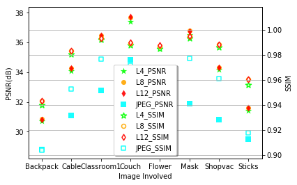

```python
%run drawFigure.py
```

```python
JPEG_PSNR
```

```
[28.8, 31.11, 32.79, 34.82, 29.99, 31.89, 30.83, 29.49]
```

```python
_ # In interactive mode, the last printed expression is assigned to the variable _
```

```
[28.8, 31.11, 32.79, 34.82, 29.99, 31.89, 30.83, 29.49]
```

## IX. How To Get Python And Packages?

**[Python 2.X or 3.X?](https://wiki.python.org/moin/Python2orPython3)**

### 1. Average Coding

a) Download Python From [Official Website](https://www.python.org/downloads/)

b) Make Sure Python Has Been Added To PATH

[figure not shown]

c) [pip](https://pip.pypa.io/en/stable/quickstart/) (Preferred Installer Program) - Python Package Manager

Type In Console: pip install packageName

...

### 2. Coding For Data Science

**What And Why Anaconda?**

Anaconda - *"The Most Popular Python Data Science Platform"*

It includes hundreds of popular data science packages and the conda package and virtual environment manager for Windows, Linux, and MacOS. Conda makes it quick and easy to install, run, and upgrade complex data science and machine learning environments like Scikit-learn, TensorFlow, and SciPy.

[figure not shown]

a) Download Anaconda From [Official Website](https://www.anaconda.com/download/) Or [Tsinghua Mirrors](https://mirrors.tuna.tsinghua.edu.cn/anaconda/archive/)

b) Make Sure Python Has Been Added To PATH

[figure not shown]

c) conda

[figure not shown]

## X. How To Get Started?

1.[用Python玩转数据](https://www.icourse163.org/course/NJU-1001571005) or other MOOC

2.[Python Tutorial 2.7.14](http://www.pythondoc.com/pythontutorial27/index.html) or [Python Tutorial 3.6.3](http://www.pythondoc.com/pythontutorial3/index.html)

3.Try some small project personally, such as [Python 图片转字符画](https://www.shiyanlou.com/courses/370)

4.Reading well-developed codes on [GitHub](https://github.com/search?utf8=✓&q=Python&type=)

## Let`s Play With Python

1.Change 'F:\Git\DataProcessingWithPython' into 'F:/Git/DataProcessingWithPython'

2.Print 1st to 30th number of Fibonacci List(1, 1, 2, 3, 5, 8, 13...)

[figure not shown]

3.Fetch the number which can`t mod 3 get 0 from 1 to 50

[figure not shown]

**Think Twice, Think Different! o.O**

## Recommanded Solutions

1.Change 'F:\Git\DataProcessingWithPython' into 'F:/Git/DataProcessingWithPython'

```python
'/'.join('F:\\Git\\DataProcessingWithPython'.split('\\'))
```

```
'F:/Git/DataProcessingWithPython'
```

2.Print 1st to 30th number of Fibonacci List(1, 1, 2, 3, 5, 8, 13...)

```python
a, b = 1, 1
for i in range(30):
    print a,
    a, b = b, a + b
```

```
1 1 2 3 5 8 13 21 34 55 89 144 233 377 610 987 1597 2584 4181 6765 10946 17711 28657 46368 75025 121393 196418 317811 514229 832040
```

3.Fetch the number which can`t mod 3 get 0 from 1 to 50

```python
for i in range(0, 51):
    if i % 3:
        print i,
```

```
1 2 4 5 7 8 10 11 13 14 16 17 19 20 22 23 25 26 28 29 31 32 34 35 37 38 40 41 43 44 46 47 49 50
```

```python
print [x for x in range(1,51) if x % 3 != 0]
```

```
[1, 2, 4, 5, 7, 8, 10, 11, 13, 14, 16, 17, 19, 20, 22, 23, 25, 26, 28, 29, 31, 32, 34, 35, 37, 38, 40, 41, 43, 44, 46, 47, 49, 50]
```

```python
print filter(lambda x:x not in range(0, 51, 3), range(0, 51))
```

```
[1, 2, 4, 5, 7, 8, 10, 11, 13, 14, 16, 17, 19, 20, 22, 23, 25, 26, 28, 29, 31, 32, 34, 35, 37, 38, 40, 41, 43, 44, 46, 47, 49, 50]
```

```python
np.array(range(1,51))[np.array(range(1,51)) % 3 != 0]
```

```
array([ 1,  2,  4,  5,  7,  8, 10, 11, 13, 14, 16, 17, 19, 20, 22, 23, 25,
       26, 28, 29, 31, 32, 34, 35, 37, 38, 40, 41, 43, 44, 46, 47, 49, 50])
```

**You Can Download All Files From My DataProcessingWithPython Repositorie On GitHub. Thanks For Your Patience!**